# ClusteringR

Guillem

18 March 2020

## Algoritmo de Kmeans

```r
(resultado_km <- kmeans(trees, centers = 3, algorithm = "MacQueen"))
```

```
## K-means clustering with 3 clusters of sizes 19, 5, 7
##
## Cluster means:
##      Girth   Height   Volume
## 1 12.52105 76.47368 25.31579
## 2  9.44000 67.20000 12.56000
## 3 17.94286 81.00000 55.92857
##
## Clustering vector:
##  [1] 2 2 2 2 1 1 2 1 1 1 1 1 1 1 1 1 1 1 1 1 1 1 1 1 3 3 3 3 3 3 3
##
## Within cluster sum of squares by cluster:
## [1] 1334.9937  100.5440  737.8914
##  (between_SS / total_SS =  77.4 %)
##
## Available components:
##
## [1] "cluster"      "centers"      "totss"        "withinss"     "tot.withinss"
## [6] "betweenss"    "size"         "iter"         "ifault"
```

¿Qué registro están en cada cluster?

```r
which(resultado_km$cluster==1)
```

```
##  [1]  5  6  8  9 10 11 12 13 14 15 16 17 18 19 20 21 22 23 24
```

```r
which(resultado_km$cluster == 2)
```

```
## [1] 1 2 3 4 7
```

¿Dónde están los centroides?

```r
resultado_km$centers
```

```
##      Girth   Height   Volume
## 1 12.52105 76.47368 25.31579
## 2  9.44000 67.20000 12.56000
## 3 17.94286 81.00000 55.92857
```

Calculamos el $SSC_i$

```r
resultado_km$withinss
```

```
## [1] 1334.9937  100.5440  737.8914
```

Calculasmos el $SSC$ toal

```r
sum(resultado_km$withinss) == resultado_km$tot.withinss
```

```
## [1] TRUE
```

```r
resultado_km$tot.withinss
```

```
## [1] 2173.429
```

$SSC$ suponiendo que sólo hubiera un cluster:

```r
resultado_km$totss
```

```
## [1] 9619.521
```

La dispersión de los centros de los clusters respecto del punto medio de todos los árboles:

```r
resultado_km$betweenss
```

```
## [1] 7446.092
```

```r
resultado_km$betweenss/resultado_km$totss
```

```
## [1] 0.7740606
```

Ejecuta sólo una vez el algoritmo de kmeans no es aconsejable debido a la aleatoriedad de los inicios del algoritmo. Por tanto, ejecutamos el algoritmo 50 veces para obtener un mínimo más óptimo

```r
iter <- 50
SSCs <- c()
for (i in 1:iter){
  SSCs <- c(SSCs, kmeans(trees, 3, algorithm = "MacQueen")$tot.withins)
}
min(SSCs)
```

```
## [1] 1860.957
```

#Clustering Jerárquico

### Distancias de datos binarios

```r
library(car)
set.seed(2020)
individuos_elegidos <- sample(1:5226, 25)
tabla_arrestados <- Arrests[individuos_elegidos, c("colour", "sex", "employed", "citizen")]
rownames(tabla_arrestados)<- 1:25
```

```r
head(tabla_arrestados, 10)
```

```
##    colour  sex employed citizen
## 1   White Male      Yes     Yes
## 2   White Male      Yes     Yes
## 3   White Male      Yes     Yes
## 4   White Male      Yes     Yes
## 5   White Male      Yes     Yes
## 6   White Male      Yes     Yes
## 7   White Male      Yes     Yes
## 8   White Male      Yes      No
## 9   Black Male       No     Yes
## 10  White Male      Yes     Yes
```

Vamos a hallar la matriz de **distancias de Hamming** entre los 25 indiviuos.

```r
tabla_arrestados$colour <- ifelse(tabla_arrestados$colour=="white", 0, 1)
tabla_arrestados$sex <- ifelse(tabla_arrestados$sex=="Male",0, 1)
tabla_arrestados$employed <- ifelse(tabla_arrestados$employed == "No", 0, 1)
tabla_arrestados$citizen <- ifelse(tabla_arrestados$citizen=="No", 0, 1)
tabla_arrestados
```

```
##    colour sex employed citizen
## 1       1   0        1       1
## 2       1   0        1       1
## 3       1   0        1       1
## 4       1   0        1       1
## 5       1   0        1       1
## 6       1   0        1       1
## 7       1   0        1       1
## 8       1   0        1       0
## 9       1   0        0       1
## 10      1   0        1       1
## 11      1   0        0       1
## 12      1   0        1       0
## 13      1   0        1       1
## 14      1   0        1       1
## 15      1   0        1       1
## 16      1   0        1       1
## 17      1   0        1       1
## 18      1   0        0       1
## 19      1   0        1       1
## 20      1   0        1       1
## 21      1   0        0       0
## 22      1   0        1       1
## 23      1   0        1       1
## 24      1   0        1       1
## 25      1   0        1       0
```

```r
as <- function(xi, xj){
  n <- length(xi)
  a0 <- length(which(xi==xj & xi == 0))
  a1 <- length(which(xi == xj & xi == 1))
  a2 <- length(which(xi != xj))
  return(c(a0, a1, a2))
}
```

La **distancia de Hamming** viene dada por la función: $\sigma_{ij} = \frac{a_1 + a_0}{a_0+a_1+a_2}$

```r
n <- dim(tabla_arrestados)[1]
matriz_dist_hamming <- matrix(1, n, n)
for (i in 1:(n-1)){
  for (j in (i+1):n){
    aux <- as(tabla_arrestados[i,],tabla_arrestados[j,])
    matriz_dist_hamming[i, j]<-(aux[1]+aux[2])/sum(aux)
    matriz_dist_hamming[j, i]<-matriz_dist_hamming[i, j]
  }
}
```

```r
matriz_dist_hamming
```

```
##       [,1] [,2] [,3] [,4] [,5] [,6] [,7] [,8] [,9] [,10] [,11] [,12] [,13]
##  [1,] 1.00 1.00 1.00 1.00 1.00 1.00 1.00 0.75 0.75  1.00  0.75  0.75  1.00
##  [2,] 1.00 1.00 1.00 1.00 1.00 1.00 1.00 0.75 0.75  1.00  0.75  0.75  1.00
##  [3,] 1.00 1.00 1.00 1.00 1.00 1.00 1.00 0.75 0.75  1.00  0.75  0.75  1.00
##  [4,] 1.00 1.00 1.00 1.00 1.00 1.00 1.00 0.75 0.75  1.00  0.75  0.75  1.00
##  [5,] 1.00 1.00 1.00 1.00 1.00 1.00 1.00 0.75 0.75  1.00  0.75  0.75  1.00
##  [6,] 1.00 1.00 1.00 1.00 1.00 1.00 1.00 0.75 0.75  1.00  0.75  0.75  1.00
##  [7,] 1.00 1.00 1.00 1.00 1.00 1.00 1.00 0.75 0.75  1.00  0.75  0.75  1.00
##  [8,] 0.75 0.75 0.75 0.75 0.75 0.75 0.75 1.00 0.50  0.75  0.50  1.00  0.75
##  [9,] 0.75 0.75 0.75 0.75 0.75 0.75 0.75 0.50 1.00  0.75  1.00  0.50  0.75
## [10,] 1.00 1.00 1.00 1.00 1.00 1.00 1.00 0.75 0.75  1.00  0.75  0.75  1.00
## [11,] 0.75 0.75 0.75 0.75 0.75 0.75 0.75 0.50 1.00  0.75  1.00  0.50  0.75
## [12,] 0.75 0.75 0.75 0.75 0.75 0.75 0.75 1.00 0.50  0.75  0.50  1.00  0.75
## [13,] 1.00 1.00 1.00 1.00 1.00 1.00 1.00 0.75 0.75  1.00  0.75  0.75  1.00
## [14,] 1.00 1.00 1.00 1.00 1.00 1.00 1.00 0.75 0.75  1.00  0.75  0.75  1.00
```

[output cut: 37 more lines]

### Distancias para datos continuos

```r
set.seed(2020)
flores_elegidas <- sample(1:150, 10)
tabla_iris <- iris[flores_elegidas,]
rownames(tabla_iris) <- 1:10
```

En primer lugar definimos una función que nos calcula la distancia euclídea entre dos vectores:

```r
dist_euclidea <- function(x, y){
  n <-length(x)
  d <- sqrt(sum((x-y)**2))
  return(d)
}
```

La matriz de distancias será la siguiente:

```r
n <- dim(tabla_iris)[1]
matriz_dist_iris <- matrix(0, n, n)
for (i in 1:(n-1)){
  for (j in (i+1):n){
    matriz_dist_iris[i,j] <- dist_euclidea(tabla_iris[i, 1:4], tabla_iris[j, 1:4])
    matriz_dist_iris[j,i]<-matriz_dist_iris[i,j]
  }
}
```

```r
round(matriz_dist_iris, 2)
```

```
##       [,1] [,2] [,3] [,4] [,5] [,6] [,7] [,8] [,9] [,10]
##  [1,] 0.00 3.79 1.58 3.89 1.29 0.71 1.08 4.30 1.71  3.86
##  [2,] 3.79 0.00 2.47 0.41 4.94 3.87 3.31 1.54 2.44  0.39
##  [3,] 1.58 2.47 0.00 2.67 2.54 1.48 0.91 2.80 0.45  2.54
##  [4,] 3.89 0.41 2.67 0.00 5.09 4.03 3.51 1.84 2.64  0.58
##  [5,] 1.29 4.94 2.54 5.09 0.00 1.19 1.74 5.23 2.63  5.00
##  [6,] 0.71 3.87 1.48 4.03 1.19 0.00 0.78 4.27 1.71  3.97
##  [7,] 1.08 3.31 0.91 3.51 1.74 0.78 0.00 3.60 1.06  3.38
##  [8,] 4.30 1.54 2.80 1.84 5.23 4.27 3.60 0.00 2.62  1.31
##  [9,] 1.71 2.44 0.45 2.64 2.63 1.71 1.06 2.62 0.00  2.44
## [10,] 3.86 0.39 2.54 0.58 5.00 3.97 3.38 1.31 2.44  0.00
```

Ahora programamos una función que calcule la **distancia de Manhatan**

```r
dist_manhatan <- function(x, y){
  n <-length(x)
  d <- sqrt(sum(abs(x-y)))
  return(d)
}
```

```r
n <- dim(tabla_iris)[1]
matriz_dist_iris <- matrix(0, n, n)
for (i in 1:(n-1)){
  for (j in (i+1):n){
    matriz_dist_iris[i,j] <- dist_manhatan(tabla_iris[i, 1:4], tabla_iris[j, 1:4])
    matriz_dist_iris[j,i]<-matriz_dist_iris[i,j]
  }
}
```

```r
round(matriz_dist_iris, 2)
```

```
##       [,1] [,2] [,3] [,4] [,5] [,6] [,7] [,8] [,9] [,10]
##  [1,] 0.00 2.55 1.61 2.57 1.41 1.10 1.30 2.76 1.79  2.53
##  [2,] 2.55 0.00 2.07 0.84 2.92 2.55 2.32 1.52 2.07  0.84
##  [3,] 1.61 2.07 0.00 2.10 2.05 1.55 1.05 2.24 0.89  2.05
##  [4,] 2.57 0.84 2.10 0.00 2.93 2.57 2.35 1.61 2.10  1.00
##  [5,] 1.41 2.92 2.05 2.93 0.00 1.41 1.76 2.90 2.05  2.90
##  [6,] 1.10 2.55 1.55 2.57 1.41 0.00 1.22 2.72 1.73  2.53
##  [7,] 1.30 2.32 1.05 2.35 1.76 1.22 0.00 2.43 1.22  2.30
##  [8,] 2.76 1.52 2.24 1.61 2.90 2.72 2.43 0.00 2.10  1.41
##  [9,] 1.79 2.07 0.89 2.10 2.05 1.73 1.22 2.10 0.00  2.05
## [10,] 2.53 0.84 2.05 1.00 2.90 2.53 2.30 1.41 2.05  0.00
```

Existe una matriz de distancias **D** entre los objetos de la tabla de datos que pueden ser sacados con la función **dist**:

```r
round(dist(tabla_iris[, 1:4]), 2)
```

```
##       1    2    3    4    5    6    7    8    9
## 2  3.79
## 3  1.58 2.47
## 4  3.89 0.41 2.67
## 5  1.29 4.94 2.54 5.09
## 6  0.71 3.87 1.48 4.03 1.19
## 7  1.08 3.31 0.91 3.51 1.74 0.78
## 8  4.30 1.54 2.80 1.84 5.23 4.27 3.60
## 9  1.71 2.44 0.45 2.64 2.63 1.71 1.06 2.62
## 10 3.86 0.39 2.54 0.58 5.00 3.97 3.38 1.31 2.44
```

```r
round(as.matrix(dist(tabla_iris[, 1:4])),2)
```

```
##       1    2    3    4    5    6    7    8    9   10
## 1  0.00 3.79 1.58 3.89 1.29 0.71 1.08 4.30 1.71 3.86
## 2  3.79 0.00 2.47 0.41 4.94 3.87 3.31 1.54 2.44 0.39
## 3  1.58 2.47 0.00 2.67 2.54 1.48 0.91 2.80 0.45 2.54
## 4  3.89 0.41 2.67 0.00 5.09 4.03 3.51 1.84 2.64 0.58
## 5  1.29 4.94 2.54 5.09 0.00 1.19 1.74 5.23 2.63 5.00
## 6  0.71 3.87 1.48 4.03 1.19 0.00 0.78 4.27 1.71 3.97
## 7  1.08 3.31 0.91 3.51 1.74 0.78 0.00 3.60 1.06 3.38
## 8  4.30 1.54 2.80 1.84 5.23 4.27 3.60 0.00 2.62 1.31
## 9  1.71 2.44 0.45 2.64 2.63 1.71 1.06 2.62 0.00 2.44
## 10 3.86 0.39 2.54 0.58 5.00 3.97 3.38 1.31 2.44 0.00
```

```r
round(dist(as.matrix(tabla_arrestados)), 2)
```

```
##       1    2    3    4    5    6    7    8    9   10   11   12   13   14   15
## 2  0.00
## 3  0.00 0.00
## 4  0.00 0.00 0.00
## 5  0.00 0.00 0.00 0.00
## 6  0.00 0.00 0.00 0.00 0.00
## 7  0.00 0.00 0.00 0.00 0.00 0.00
## 8  1.00 1.00 1.00 1.00 1.00 1.00 1.00
## 9  1.00 1.00 1.00 1.00 1.00 1.00 1.00 1.41
## 10 0.00 0.00 0.00 0.00 0.00 0.00 0.00 1.00 1.00
## 11 1.00 1.00 1.00 1.00 1.00 1.00 1.00 1.41 0.00 1.00
## 12 1.00 1.00 1.00 1.00 1.00 1.00 1.00 0.00 1.41 1.00 1.41
## 13 0.00 0.00 0.00 0.00 0.00 0.00 0.00 1.00 1.00 0.00 1.00 1.00
## 14 0.00 0.00 0.00 0.00 0.00 0.00 0.00 1.00 1.00 0.00 1.00 1.00 0.00
## 15 0.00 0.00 0.00 0.00 0.00 0.00 0.00 1.00 1.00 0.00 1.00 1.00 0.00 0.00
```

[output cut: 35 more lines]

### Escalado de datos

Si no queremos que la variación de los datos intervenga en el análisis de las distancias posterior debemos escalar los datos restando su media y dividiendo por su desviación típica.

```r
tabla_iris_escalada <- scale(tabla_iris[, 1:4])
tabla_iris_escalada
```

```
##    Sepal.Length Sepal.Width Petal.Length Petal.Width
## 1    1.48995708  0.15440550    0.8346116   0.7949984
## 2   -0.82453935  1.31244678   -1.0072898  -0.9539981
## 3   -0.10125922 -0.23160826    0.2014580   0.4769990
## 4   -0.39057127  1.69846054   -1.1224087  -0.9539981
## 5    1.48995708 -1.00363577    1.4677652   1.2719975
## 6    0.62202092 -0.03860138    0.9497304   1.2719975
## 7    0.04339681 -0.42461514    0.7194927   0.4769990
## 8   -1.69247552 -1.38964953   -1.1224087  -1.1129978
## 9    0.04339681 -0.81062889    0.1438985   0.0000000
## 10  -0.67988333  0.73342614   -1.0648492  -1.2719975
## attr(,"scaled:center")
## Sepal.Length  Sepal.Width Petal.Length  Petal.Width
##         5.67         3.02         3.25         1.00
## attr(,"scaled:scale")
## Sepal.Length  Sepal.Width Petal.Length  Petal.Width
##    0.6912951    0.5181162    1.7373351    0.6289321
```

```r
(apply(tabla_iris_escalada, 2, mean))
```

```
##  Sepal.Length   Sepal.Width  Petal.Length   Petal.Width
##  1.360132e-16 -6.664591e-17  2.775558e-17  2.219362e-17
```

```r
apply(tabla_iris_escalada, 2, sd)
```

```
## Sepal.Length  Sepal.Width Petal.Length  Petal.Width
##            1            1            1            1
```

Observamos que su media es 0 y su desviación típica es 1.

### Clustering Jerárquico paso a paso

```r
matriz_nueva <-matriz_dist_iris
diag(matriz_nueva)<-max(matriz_dist_iris)
(flores_min <- which(matriz_nueva == min(matriz_nueva), arr.ind = TRUE))
```

```
##      row col
## [1,]   4   2
## [2,]   2   4
```

Observamos que las flores 4 y 2 son las más cercanas

```r
sum(matriz_dist_iris[4] - matriz_dist_iris[2])
```

```
## [1] 0.01953676
```

$$d(C, C_1 + C_2) = min(d(C, C_1), d(C, C_2))$$
y así sucesivamente hasta alcanzar un solo clúster

### Clustering Jerárquico algomerativo

```r
clustering_jer <- hclust(dist(tabla_iris[,1:4]), method = "single")
```

```r
clustering_jer$merge
```

```
##       [,1] [,2]
##  [1,]   -2  -10
##  [2,]   -4    1
##  [3,]   -3   -9
##  [4,]   -1   -6
##  [5,]   -7    4
##  [6,]    3    5
##  [7,]   -5    6
##  [8,]   -8    2
##  [9,]    7    8
```

Primero se agrupa la flor 2 y 10. Seguidamente la flor 4 se une al cluster 1. La tercera iteración une la flor 3 y la 9. Y así sucesivamente hasta que se une los últimos clusters creados (7 y 8).

```r
clustering_jer$height
```

```
## [1] 0.3872983 0.4123106 0.4472136 0.7071068 0.7810250 0.9110434 1.1916375
## [8] 1.3114877 2.4351591
```

`height` nos muestra a qué distancia se producen las agrupacios de cada iteración del metodo `merge`

### Dibujar un dendrograma

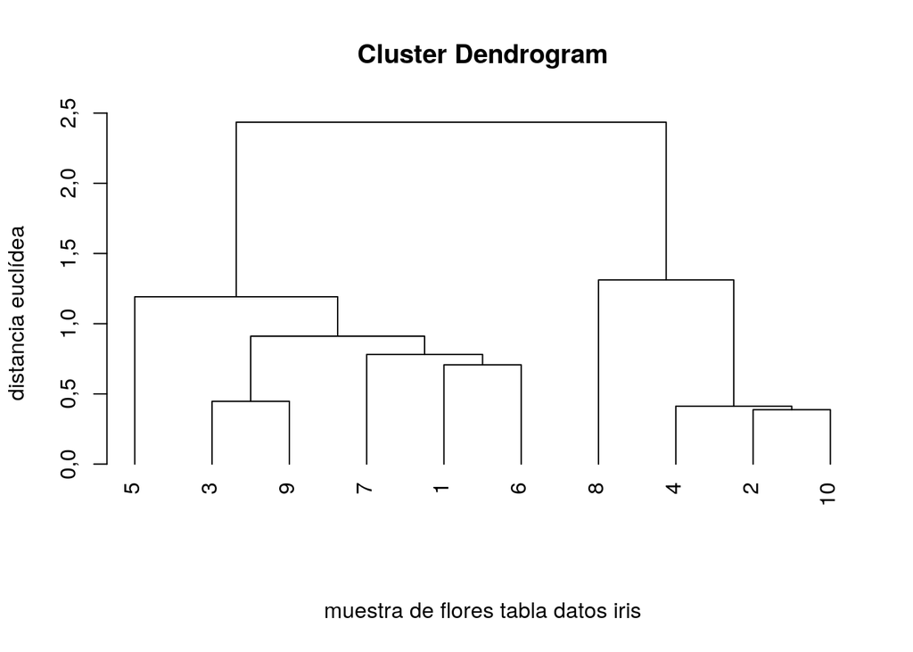

```r
plot(clustering_jer, hang = -1, xlab = "muestra de flores tabla datos iris", sub = "", ylab = "distancia euclídea")
```

Para calcular los clusters utilizamos la funcion `cutree`

```r
cutree(clustering_jer, k = 3)
```

```
##  1  2  3  4  5  6  7  8  9 10
##  1  2  1  2  1  1  1  3  1  2
```

```r
cutree(clustering_jer, h = 1.5)
```

```
##  1  2  3  4  5  6  7  8  9 10
##  1  2  1  2  1  1  1  2  1  2
```

Si queremos visualizar los clusters en el dendograma usamos la funcion `rect.hclust`

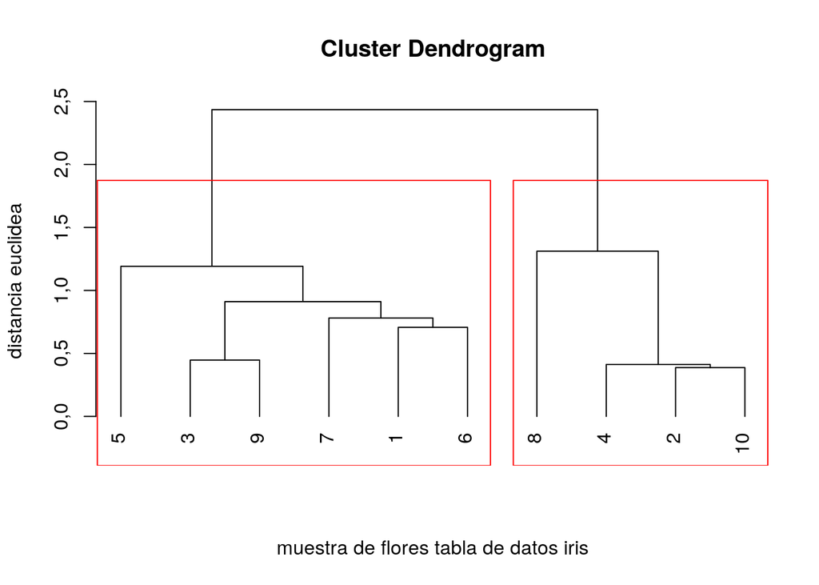

```r
plot(clustering_jer, hang = -1, xlab = "muestra de flores tabla de datos iris", ylab = "distancia euclidea", sub = "",labels = 1:10)
rect.hclust(clustering_jer, h = 1.5)
```

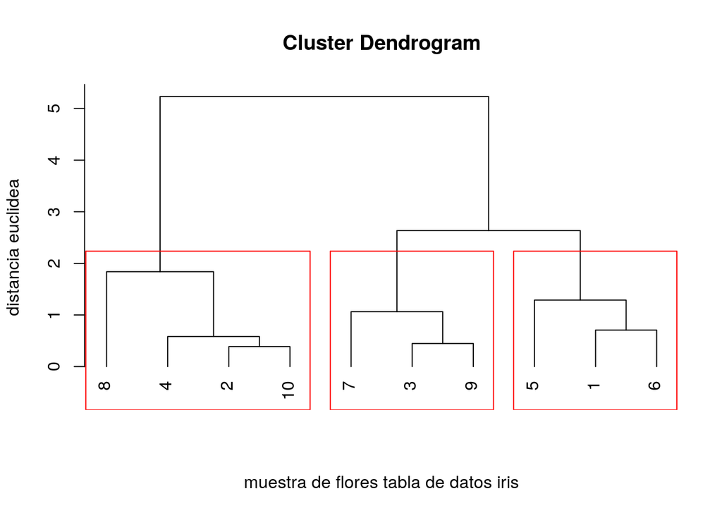

```r
clustering_irir_completo <- hclust(dist(tabla_iris[,1:4]), method = "complete")
plot(clustering_irir_completo, hang = -1, xlab = "muestra de flores tabla de datos iris", sub="", ylab = "distancia euclidea", label = 1:10)
rect.hclust(clustering_irir_completo, h = 2)
```

Para hacer clusters con datos binarios

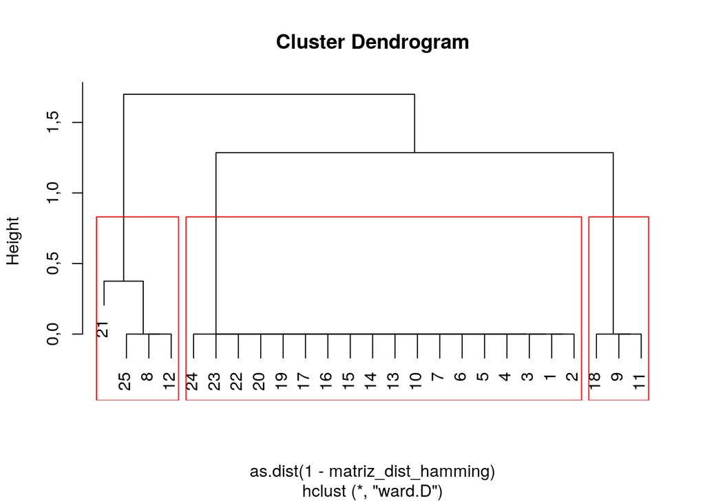

```r
clustering_arrestado <- hclust(as.dist(1-matriz_dist_hamming), method = "ward.D")
plot(clustering_arrestado)
rect.hclust(clustering_arrestado, h = 0.5)
```

```r
prueba <- cbind(mtcars[1], mtcars[4], mtcars[6:7])
kmeans(prueba, centers = 4, algorithm = "Lloyd", trace = "Manhattan")
```

```
## K-means clustering with 4 clusters of sizes 9, 6, 5, 12
##
## Cluster means:
##        mpg       hp       wt     qsec
## 1 16,40000 174,4444 3,760000 17,19111
## 2 13,91667 255,6667 4,153167 15,93167
## 3 29,68000  62,2000 2,155000 19,35800
## 4 21,95000 106,5833 2,784833 18,67167
##
## Clustering vector:
##           Mazda RX4       Mazda RX4 Wag          Datsun 710      Hornet 4 Drive
##                   4                   4                   4                   4
##   Hornet Sportabout             Valiant          Duster 360           Merc 240D
##                   1                   4                   2                   3
##            Merc 230            Merc 280           Merc 280C          Merc 450SE
##                   4                   4                   4                   1
##          Merc 450SL         Merc 450SLC  Cadillac Fleetwood Lincoln Continental
##                   1                   1                   1                   2
##   Chrysler Imperial            Fiat 128         Honda Civic      Toyota Corolla
##                   2                   3                   3                   3
##       Toyota Corona    Dodge Challenger         AMC Javelin          Camaro Z28
##                   4                   1                   1                   2
##    Pontiac Firebird           Fiat X1-9       Porsche 914-2        Lotus Europa
##                   1                   3                   4                   4
##      Ford Pantera L        Ferrari Dino       Maserati Bora          Volvo 142E
##                   2                   1                   2                   4
##
## Within cluster sum of squares by cluster:
## [1] 2294,8242 8936,2265  203,2141 1449,9090
##  (between_SS / total_SS =  91,2 %)
##
## Available components:
##
## [1] "cluster"      "centers"      "totss"        "withinss"     "tot.withinss"
## [6] "betweenss"    "size"         "iter"         "ifault"
```

```r
pure <- hclust(dist(scale(prueba)), method = "complete")
pure$merge
```

```
##       [,1] [,2]
##  [1,]  -15  -16
##  [2,]  -22  -23
##  [3,]  -12  -13
##  [4,]   -7  -24
##  [5,]   -1   -2
##  [6,]  -10  -11
##  [7,]   -5  -25
##  [8,]  -14    3
##  [9,]  -18  -20
## [10,]   -3  -32
## [11,]  -19  -26
## [12,]   -4   -6
## [13,]    2    8
## [14,]  -17    1
```

[output cut: 17 more lines]

```r
prueba[15:16,]
```

```
##                      mpg  hp    wt  qsec
## Cadillac Fleetwood  10,4 205 5,250 17,98
## Lincoln Continental 10,4 215 5,424 17,82
```

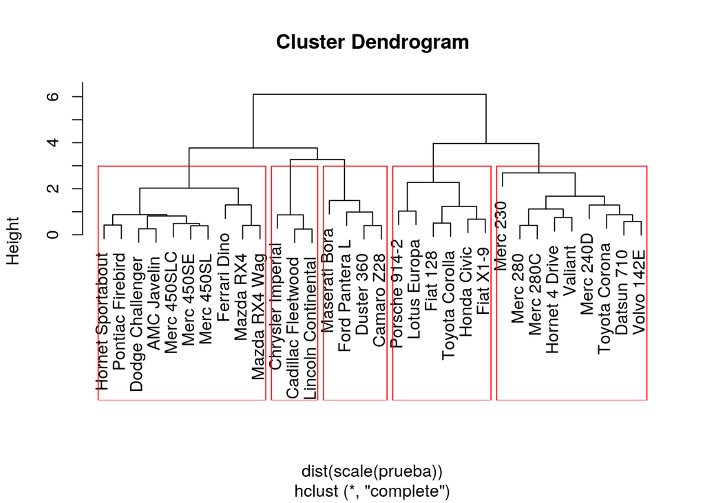

```r
prueba <- cbind(mtcars[1], mtcars[4], mtcars[6:7])
pure <- hclust(dist(scale(prueba)), method = "complete")
plot(pure)
rect.hclust(pure, k = 5)
```